# About me

2020-15-10

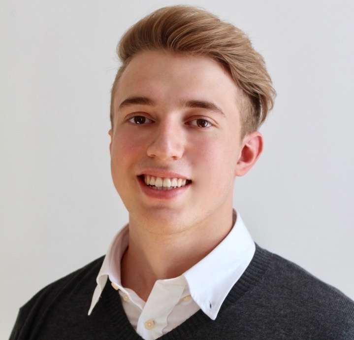

I’m an Financial Analysis (MFA) student at London Business School (2021).

I have done my undergrad at the Vienna University of Business and Economics and due to my passion to mathematics, I also completed nearly half of the studies in Financial Mathematics besides my Business degree. I always was really keen to learn as much new things as possible & therefore constantly try to widen my horizon. LBS perfectly supports me with this objective, providing an environment with students from all over the world and first class lecturers.

Regarding my professional experience, I have gained most of my experience in Consulting and Investment Banking. Although I enjoyed both internships to the fullest, as of today I think that my long term objective is to work for one of the leading Hedge or PE funds. In my opinion, this profession is the most demanding one, and it enables one to really see the performance of my own actions and decisions.

Besides my studies I am actively engaged in supporting fellow LBS colleagues with their careers as one of the elected career reps of my cohort. Furthermore, I am part of the executive board of the DACH club and organize gatherings & diverse events (speaker series, running dinners, etc.) as Head of social engagement.

Not so long ago, I played Volleyball on a quite professional level. Due to changes in my personal life and a major injury I, however, was forced to give up this extensive level of sport. In my free time I anyways enjoy playing volleyball, tennis, golf and ski with my friends. Additionally, I am always in for other informal social gatherings (such as dinners, parties, etc.)